# Modelling the GC-content bias with polynomial regression

Ido Shalom, Daniel Rodan, Sagi Levin

18 June, 2024

### Libraries used

```r
# Load libraries

library("ggplot2")
library("data.table")
library("tictoc")
library("manipulate")
library(tidyverse)
library(fitdistrplus)
library(dplyr)
library(ggthemes)
library(scales)
library(gridExtra)
```

### Paths and Data

```r
# Load the data
load(file = 'data/reads_gc_5K.rda')
```

## Introduction

In this week’s task, we aim to further investigate the relationship between GC content and coverage (number of reads), using segmental polynomial regression and residual analysis to understand the correlation between them.

### Part A : Segmental polynomial regression

we have created a logical index to filter our data based on specific conditions:

read coverage less than or equal to 500, and GC content between 0.25 and 0.65.

Using this index, we filtered the GC content and read coverage data to include only the values that meet these criteria.

Finally, we plotted the filtered data, showing the relationship between GC content and read coverage.

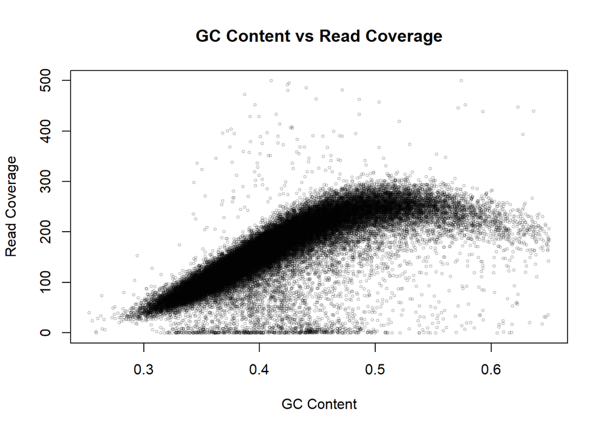

```r
if(any(GC_5K>1)){ # This makes sure we don't repeat the command
  GC_5K = GC_5K / 5000
}

# Create a logical index for outliers
filtered_index <- (reads_5K <= 500) & (GC_5K >= 0.25) & (GC_5K <= 0.65)

# Apply the index to filter the data
GC_5K_filtered <- GC_5K[filtered_index]
reads_5K_filtered <- reads_5K[filtered_index]

# Plot the data
plot(GC_5K_filtered, reads_5K_filtered, col=rgb(0,0,0,0.2), ylim = c(0,500), cex = 0.5, xlab = "GC Content", ylab = "Read Coverage", main = "GC Content vs Read Coverage")
```

**Results Explanations:**

The plot looks similar to what we saw in class.

As GC content goes up from 0.25 to about 0.5, the read coverage also goes up, showing a positive correlation between them. However, when GC content goes above 0.5, the read coverage levels off and slightly drops.

This matches what we discussed in class, where we found that a linear trend is not quite a good representation of the connection between GC content and coverage, so we might want to find the functional connection through segmental polynomial regression - which we did below:

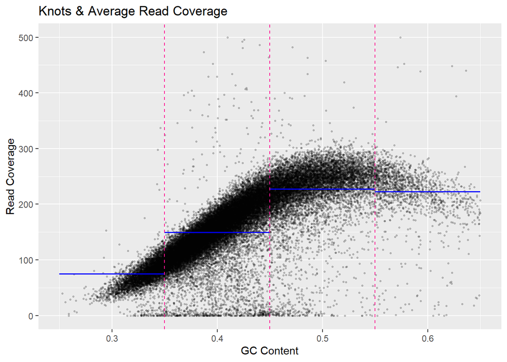

```r
# Define the knots
knots <- seq(0.25, 0.65, by = 0.1)

# Calculate the averages for each knot
knot_averages <- sapply(1:(length(knots) - 1), function(i) {
  mean(reads_5K_filtered[GC_5K_filtered >= knots[i] & GC_5K_filtered < knots[i + 1]], na.rm = TRUE)
})

# Create a data frame for the averages
average_data <- data.frame(
  GC_content_start = knots[-length(knots)],
  GC_content_end = knots[-1],
  avg_read_coverage = knot_averages
)

# Plot data points and average in each knot as horizontal lines
ggplot() +
  geom_point(aes(x = GC_5K_filtered, y = reads_5K_filtered), alpha = 0.2, size = 0.5) +
  geom_segment(data = average_data, aes(x = GC_content_start, xend = GC_content_end,
                                        y = avg_read_coverage, yend = avg_read_coverage),
               color = "blue", size = 0.634) +
  geom_vline(xintercept = c(0.35, 0.45, 0.55), linetype = "dashed", color = "deeppink") +
  labs(title = "Knots & Average Read Coverage",
       x = "GC Content",
       y = "Read Coverage") +
  xlim(0.25, 0.65) +
  ylim(0, 500)
```

**Results Explanations:**

So, this plot is the preparation for the segmental polynomial regression, where we define specific knots as vertical dashed lines at 0.35, 0.45, and 0.55.

For each segment defined by the knots, we calculate the average read coverage to better observe changes in trends.

We can already see why the linear regression did not work - the average read coverage decreases in the 0.55-0.65 GC content interval.

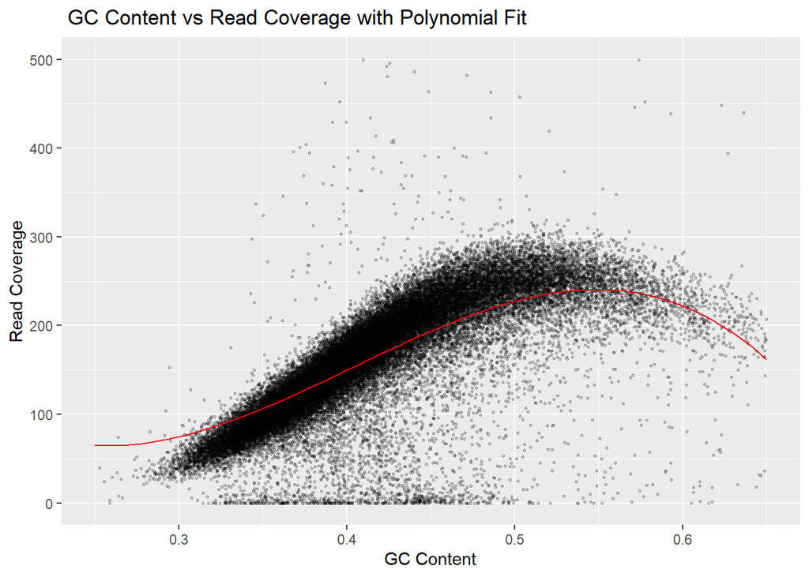

```r
# Fit a polynomial regression model of degree 3
average_midpoints <- (average_data$GC_content_start + average_data$GC_content_end) / 2
poly_model <- lm(avg_read_coverage ~ poly(average_midpoints, 3), data = average_data)

# Generate predictions for the polynomial model
predicted_gc <- seq(0.25, 0.65, length.out = 100)
predicted_reads <- predict(poly_model, newdata = data.frame(average_midpoints = predicted_gc))

# smooth polynomial line that fits the data
ggplot() +
  geom_point(aes(x = GC_5K_filtered, y = reads_5K_filtered), alpha = 0.2, size = 0.5) +
  geom_line(aes(x = predicted_gc, y = predicted_reads), color = "red") +
  labs(title = " GC Content vs Read Coverage with Polynomial Fit",
       x = "GC Content",
       y = "Read Coverage") +
  xlim(0.25, 0.65) +
  ylim(0, 500)
```

**Results Explanations:**

At first glance, it seems like the polynomial fit captures the trend in the data more accurately than a linear model, showing the initial increase in read coverage with GC content, a peak, and then a decrease as GC content goes beyond 0.5.

This visualization does confirm the nonlinear relationship between GC content and read coverage, but we might want some numerical evidence for that, which we will address in part C.

### Part 2 : Analysis of residuals against GC content

Now, We want to analyze the residuals from the polynomial regression model to determine if there was any bias for certain GC content values.

We plotted these residuals against the GC content to visually inspect for any patterns.

The plot will show us whether the residuals were randomly scattered around zero, indicating no bias, or if there was a systematic bias for specific GC ranges.

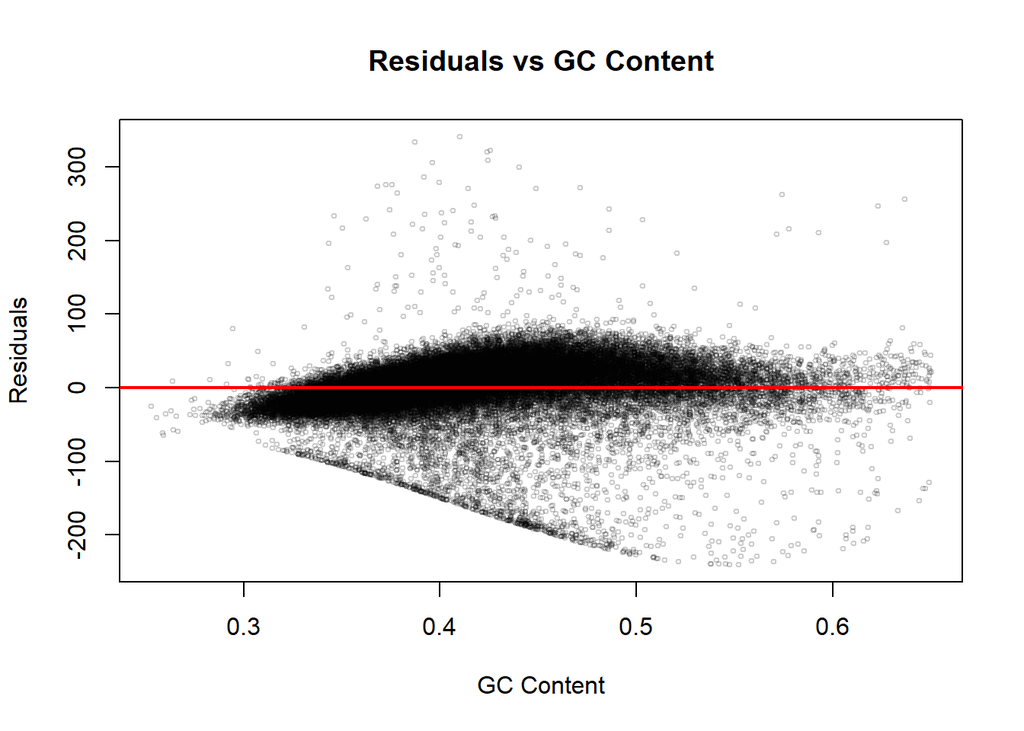

```r
# Generate predictions for polynomial model
predicted_reads_filtered <- predict(poly_model, newdata = data.frame(average_midpoints = GC_5K_filtered))

# Calculate the residuals
residuals <- reads_5K_filtered - predicted_reads_filtered

# Plot the residuals against the GC content
plot(GC_5K_filtered, residuals, xlab = "GC Content", ylab = "Residuals", main = "Residuals vs GC Content", col=rgb(0,0,0,0.2), cex = 0.5)
abline(h = 0, col = "red", lwd = 2)  # Add a horizontal line at y = 0 for reference
```

**Results Explanations:**

There still appears to be some bias for certain GC values, but the polynomial model is significantly better in this regard.

There is a small but noticeable pattern where the residuals are more dispersed at higher GC content values, indicating that the model’s predictions are less accurate in these regions.

This suggests that while the polynomial model improves the fit compared to a linear model, it does not completely eliminate biases for certain GC content values.

### Part 3 : Numerical measure of the quality of the prediction

We evaluated the quality of the polynomial regression model’s predictions by comparing it to a simpler linear regression model.

We fit a linear model to the same filtered data and calculated the residual sum of squares (RSS) for both models.

By comparing the RSS values, we determined the improvement factor of the polynomial model over the linear model.

This factor indicates how many times better the polynomial model fits the data compared to the linear model.

We also calculated the R-squared for each model for reference.

```r
# Fit a linear regression model to the filtered data
linear_model <- lm(reads_5K_filtered ~ GC_5K_filtered)

# Generate predictions for the linear model
predicted_reads_linear <- predict(linear_model)

# Calculate the RSS for the polynomial model
rss_poly <- sum((reads_5K_filtered - predicted_reads_filtered)^2)

# Calculate the RSS for the linear model
rss_linear <- sum((reads_5K_filtered - predicted_reads_linear)^2)

# Calculate R-squared for both models
ss_total <- sum((reads_5K_filtered - mean(reads_5K_filtered))^2)
r_squared_poly <- 1 - rss_poly / ss_total
r_squared_linear <- 1 - rss_linear / ss_total

# Calculate the improvement factor
improvement_factor <- rss_linear / rss_poly

# Print the results
cat("R-squared for the polynomial model:", r_squared_poly, "\n")
```

```
## R-squared for the polynomial model: 0.6394822
```

```r
cat("R-squared for the linear model:", r_squared_linear, "\n")
```

```
## R-squared for the linear model: 0.57839
```

```r
cat("Improvement factor (linear RSS / polynomial RSS):", improvement_factor, "\n")
```

```
## Improvement factor (linear RSS / polynomial RSS): 1.169457
```

**Results Explanations:**

The R-squared for the polynomial model is 0.6394822, indicating that approximately 63.95% of the variability in read coverage can be explained by the polynomial regression. In contrast, the R-squared for the linear model is 0.57839, meaning it explains about 57.84% of the variability.

Additionally, the improvement factor is 1.169457, which indicates that the polynomial model fits the filtered data approximately 1.17 times better than the linear model.

### Part 4 :Magnitude of the residuals between different CG values

We want to examine the differences in residual magnitude across various GC content values.

We plotted the residuals against GC content, with a smooth trend line added to visualize the trend.

Furthermore, we conducted a small numerical analysis by calculating summary statistics for residuals within each GC content bin, as defined by the knots.

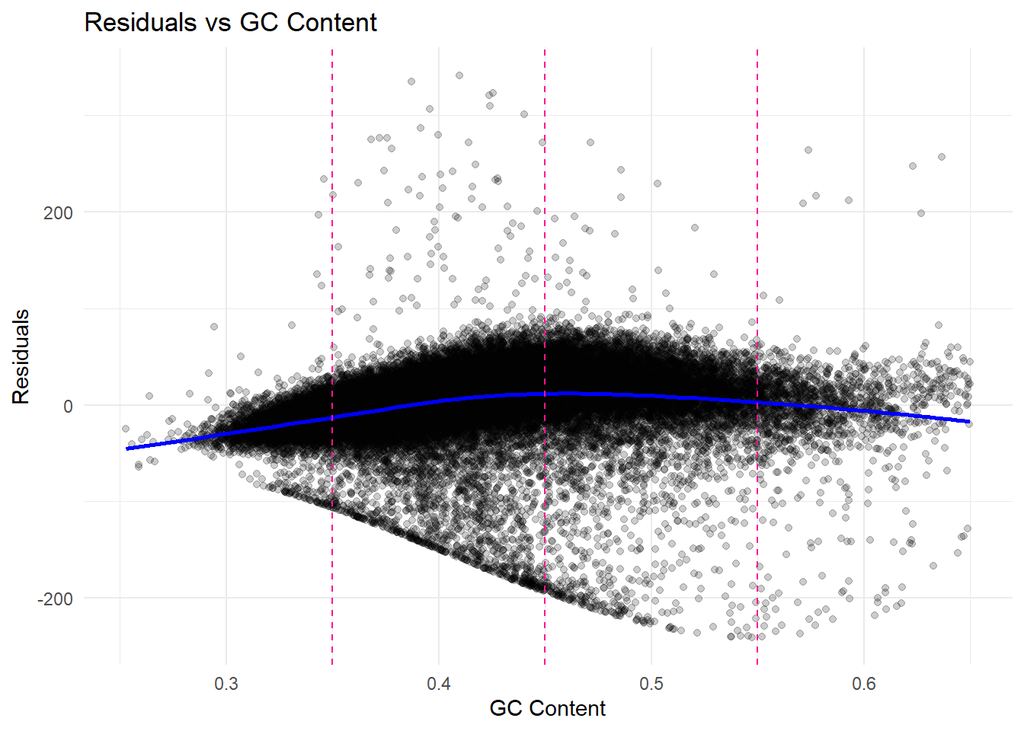

```r
# Ensure no missing values
residuals_df <- data.frame(GC_content = GC_5K_filtered, Residuals = residuals)
residuals_df <- na.omit(residuals_df)

# Plot residuals against GC content
suppressMessages({
  ggplot(residuals_df, aes(x = GC_content, y = Residuals)) +
    geom_point(alpha = 0.2) +
    geom_smooth(formula = y ~ x,method = "loess", color = "blue", se = FALSE, show.legend = FALSE) +
    geom_vline(xintercept = 0.35, linetype = "dashed", color = "deeppink") +
    geom_vline(xintercept = 0.45, linetype = "dashed", color = "deeppink") +
    geom_vline(xintercept = 0.55, linetype = "dashed", color = "deeppink") +
    labs(title = "Residuals vs GC Content",
         x = "GC Content",
         y = "Residuals") +
    theme_minimal()
})
```

```r
# Bin the GC content
bins <- cut(GC_5K_filtered, breaks = seq(0.25, 0.65, by = 0.1), include.lowest = TRUE)

# Statistics for residuals within each bin
summary_stats <- tapply(residuals, bins, function(x) {
  c(mean = mean(x), sd = sd(x))
})

# Summary data frame
summary_df <- as.data.frame(do.call(rbind, summary_stats))
print(summary_df)
```

```
##                   mean       sd
## [0.25,0.35] -19.202723 18.79485
## (0.35,0.45]   1.809240 36.21698
## (0.45,0.55]   9.542187 46.65209
## (0.55,0.65]  -6.011634 48.37537
```

**Results Explanations:**

This may indicate a bias in extreme values of GC content in terms of the number of reads per cell.

## Short summary

We think that overall, the polynomial regression model provided a more accurate representation of the data, but we are not quite sure that even this method is the best way to capture the connection between GC content and coverage.

Further limitations and adjustments to the degree of the polynomial may be needed.